# Self-Driving Car Engineer Nanodegree

## Project: Build a Traffic Sign Recognition Classifier

In this notebook, a template is provided for you to implement your functionality in stages which is required to successfully complete this project. If additional code is required that cannot be included in the notebook, be sure that the Python code is successfully imported and included in your submission, if necessary. Sections that begin with **'Implementation'** in the header indicate where you should begin your implementation for your project. Note that some sections of implementation are optional, and will be marked with **'Optional'** in the header.

In addition to implementing code, there will be questions that you must answer which relate to the project and your implementation. Each section where you will answer a question is preceded by a **'Question'** header. Carefully read each question and provide thorough answers in the following text boxes that begin with **'Answer:'**. Your project submission will be evaluated based on your answers to each of the questions and the implementation you provide.

> **Note:** Code and Markdown cells can be executed using the **Shift + Enter** keyboard shortcut. In addition, Markdown cells can be edited by typically double-clicking the cell to enter edit mode.

## Step 1: Dataset Exploration

Visualize the German Traffic Signs Dataset. This is open ended, some suggestions include: plotting traffic signs images, plotting the count of each sign, etc. Be creative!

The pickled data is a dictionary with 4 key/value pairs:

- features -> the images pixel values, (width, height, channels)
- labels -> the label of the traffic sign
- sizes -> the original width and height of the image, (width, height)
- coords -> coordinates of a bounding box around the sign in the image, (x1, y1, x2, y2). Based the original image (not the resized version).

```python
# Load pickled data
import pickle
import math

import time
from datetime import timedelta

import numpy as np
import tensorflow as tf
from tqdm import tqdm
import matplotlib.pyplot as plt
import matplotlib.gridspec as gridspec
import random
from datetime import datetime

from sklearn.model_selection import train_test_split
from sklearn.preprocessing import LabelBinarizer
from sklearn.utils import resample
from tqdm import tqdm


# TODO: fill this in based on where you saved the training and testing data
training_file = "train.p"
testing_file = "test.p"

with open(training_file, mode='rb') as f:
    train = pickle.load(f)
with open(testing_file, mode='rb') as f:
    test = pickle.load(f)

X_train, y_train = train['features'], train['labels']
X_test, y_test = test['features'], test['labels']
```

```python
### To start off let's do a basic data summary.
X_arr = np.array(X_train)
# TODO: number of training examples
n_train = len(X_arr)

# TODO: number of testing examples
n_test = len(np.array(X_test))

# TODO: what's the shape of an image?
#features = tf.placeholder(tf.float32)

image_shape = len(X_arr[0]) * len(X_arr[0][0])

# TODO: how many classes are in the dataset
y_arr = np.array(y_train)
y_unique = np.unique(y_arr)
n_classes = len(y_unique)

print("Number of training examples =", n_train)
print("Number of testing examples =", n_test)
print("Image data shape =", image_shape)
print("Number of classes =", n_classes)
```

```
Number of training examples = 39209
Number of testing examples = 12630
Image data shape = 1024
Number of classes = 43
```

```
2016-12-09 18:34:18.441929
2016-12-09 18:34:38.996956
```

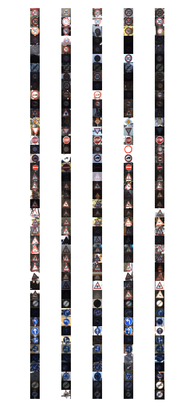

```python
### Data exploration visualization goes here.
### Feel free to use as many code cells as needed.
from PIL import Image


print(datetime.now())
sample_size = 5 #five images per class label
count = 0 #book keeping for plots

#Set GridSpec
# Rows: Classes (or labels)
# Columns: number of images/class


gspec = gridspec.GridSpec(n_classes, sample_size, wspace=0.0, hspace=0.0)
fig = plt.figure(figsize=(4, 10))

#labelset_pbar = tqdm(range(n_labels), desc='Sample test images', unit='labels')

for i in range(n_classes):
    ind = y_train == i
    subset_x = X_train[ind,] #get all images that belong to class i
    #print(subset_x)

    for x in range(sample_size):
        img = random.choice(subset_x)
        #print(subset_x.shape)
        #s_plot = plt.subplot(n_classes,sample_size,count)
        s_plot = plt.Subplot(fig,gspec[count])
        s_plot.set_xticks([])
        s_plot.set_yticks([])
        s_plot.imshow(img, cmap='gray')
        plt.axis('off')
        fig.add_subplot(s_plot)
        #plt.imshow(img)
        count += 1
        result = Image.fromarray(img)
        if count > 214:
            break

print(datetime.now())
plt.show()
```

## Step 2: Design and Test a Model Architecture

Design and implement a deep learning model that learns to recognize traffic signs. Train and test your model on the [German Traffic Sign Dataset](http://benchmark.ini.rub.de/?section=gtsrb&subsection=dataset).

There are various aspects to consider when thinking about this problem:

- Your model can be derived from a deep feedforward net or a deep convolutional network.
- Play around preprocessing techniques (normalization, rgb to grayscale, etc)
- Number of examples per label (some have more than others).
- Generate fake data.

Here is an example of a [published baseline model on this problem](http://yann.lecun.com/exdb/publis/pdf/sermanet-ijcnn-11.pdf). It's not required to be familiar with the approach used in the paper but, it's good practice to try to read papers like these.

### Implementation

Use the code cell (or multiple code cells, if necessary) to implement the first step of your project. Once you have completed your implementation and are satisfied with the results, be sure to thoroughly answer the questions that follow.

```python
### Preprocess the data here.
### Feel free to use as many code cells as needed.

from tensorflow.python.ops.variables import Variable



#1. Normalize features

# Convert image to grayscale

def color2gray(image):
   gray = 0.2989 * image[:,:,0] + 0.5870 * image[:,:,1] + 0.1140 * image[:,:,2]
   return gray

def pre_process_image(image):

    image = color2gray(image)
    return image.flatten()/255.

train_features = np.array([pre_process_image(X_train[i]) for i in range(len(X_train))],
                          dtype = np.float32)
test_features = np.array([pre_process_image(X_test[i]) for i in range(len(X_test))],
                          dtype = np.float32)
```

```python
# 2. Turn labels into numbers and apply One-Hot Encoding

encoder = LabelBinarizer()
encoder.fit(y_train)
train_labels = encoder.transform(y_train)
test_labels = encoder.transform(y_test)

# Change to float32, so that it can be multiplied against the features in TensorFlow which are float32
train_labels = train_labels.astype(np.float32)
test_labels = test_labels.astype(np.float32)
is_labels_encod = True

print ('Labels One-Hot Encoded')
```

```
Labels One-Hot Encoded
```

```python
#3. Randomize to get validation features and labels set


# Get randomized datasets for training and validation
train_features, valid_features, train_labels, valid_labels = train_test_split(
    train_features,
    train_labels,
    test_size=0.05,
    random_state=832289)

#print ('Training features and labels randomized and split')
```

```python
### Preprocess the data here.
### Feel free to use as many code cells as needed.
import tensorflow as tf

features_count = train_features.shape[1]
labels_count = train_labels.shape[1]

print(features_count)
print(labels_count)


features = tf.placeholder(tf.float32, [None, train_features.shape[1]])
labels = tf.placeholder(tf.float32, [None, train_labels.shape[1]])
keep_prob = tf.placeholder(tf.float32)

train_dict = {features: train_features, labels: train_labels, keep_prob: 0.5}
valid_dict = {features: valid_features, labels: valid_labels, keep_prob: 1.0}
test_dict = {features: test_features, labels: test_labels, keep_prob: 1.0}


#Linear Function WX + b
#logits = tf.matmul(features, weights) + biases

#Hidden Layer

n_hidden_layer = 256 # layer number of features
weights = {
    'hidden_layer_1': tf.Variable(tf.random_normal([features_count, n_hidden_layer])),
    'hidden_layer_2': tf.Variable(tf.random_normal([n_hidden_layer, labels_count])),
}
biases = {
    'hidden_layer_1': tf.Variable(tf.random_normal([n_hidden_layer])),
    'hidden_layer_2': tf.Variable(tf.random_normal([labels_count]))
}

layer_1 = tf.add(tf.matmul(features, weights['hidden_layer_1']), biases['hidden_layer_1'])
layer_1 = tf.nn.relu(layer_1)
layer_1 = tf.nn.dropout(layer_1, keep_prob)
layer_2 = tf.add(tf.matmul(layer_1, weights['hidden_layer_2']), biases['hidden_layer_2'])


prediction = tf.nn.softmax(layer_2)
cross_entropy = tf.reduce_mean(-tf.reduce_sum(labels * tf.log(tf.clip_by_value(prediction,1e-10,1.0)),
                                              reduction_indices=[1]))




#Training loss
loss = tf.reduce_mean(cross_entropy)
print ("loss ", loss)

# Create an operation that initializes all variables
init = tf.initialize_all_variables()

# Test Cases
with tf.Session() as session:
    session.run(init)
    session.run(loss, feed_dict = train_dict)
    session.run(loss, feed_dict = test_dict)
    biases_data = session.run(biases)

#assert not np.count_nonzero(biases_data), 'biases must be zeroes'

print ('Tests passed')
```

```
1024
43
loss  Tensor("Mean_1:0", shape=(), dtype=float32)
Tests passed
```

```python
# Determine if the predictions are correct
is_correct_prediction = tf.equal(tf.argmax(prediction, 1), tf.argmax(labels, 1))
print ('is_correct_prediction', is_correct_prediction)
#Calculate the accuracy of the predictions
accuracy = tf.reduce_mean(tf.cast(is_correct_prediction, tf.float32))
print ('accuracy', accuracy)
print('Accuracy function created')
```

```
is_correct_prediction Tensor("Equal:0", shape=(?,), dtype=bool)
accuracy Tensor("Mean_2:0", shape=(), dtype=float32)
Accuracy function created
```

### Question 1

*Describe the techniques used to preprocess the data.*

**Answer:**

```python
### Generate data additional (if you want to!)
### and split the data into training/validation/testing sets here.
### Feel free to use as many code cells as needed.

'''
I went through 2 steps of preprocessing my data:

Step 1: Flatten images to grayscale

Rather than modifying the images, I started by flattening them to grayscale. I took the shape of the training
and testing features and reshaped them into 2-D. Unfortunately, I could not import cv2, so I used an alternative
method to normalize the features.

Step 2: One Hot Endocing

Finally, I applied One-Hot Encoding to the testing and training labels. One-Hot Encoding is a helpful
way to represent our labels mathematically. After applying it, the probabilities for the correct
class are close to 1, while the rest are all 0.


'''
```

### Question 2

*Describe how you set up the training, validation and testing data for your model. If you generated additional data, why?*

**Answer:**

```python
### Define your architecture here.
### Feel free to use as many code cells as needed.


'''
To split the data, I first read in the train.p file, and saved the 'features' and 'labels' data
into X_train and y_train. I did the same thing for test.p. After this, I used the sklearn.model_selection
to import train_test_split and saved parts of the training features and labels into my validation
features and labels, called valid_features and valid_labels.



'''
```